# 問題6.4

> 問題4.5でダウンロードしたデータを用いて以下の問に答えよ．

「問題4.5でダウンロードしたデータ」を読み込む

```r
library(tidyverse)
msci_day <- read_csv("msci_day.csv")
msci_day
```

A spec_tbl_df: 1391 × 8

| Date <date> | ca <dbl> | fr <dbl> | ge <dbl> | it <dbl> | jp <dbl> | uk <dbl> | us <dbl> |
| --- | --- | --- | --- | --- | --- | --- | --- |
| 2003-01-01 | 560.099 | 902.081 | 724.932 | 290.187 | 1593.175 | 791.076 | 824.583 |
| 2003-01-02 | 574.701 | 927.206 | 768.150 | 296.963 | 1578.214 | 797.813 | 852.219 |
| 2003-01-03 | 580.212 | 929.297 | 768.411 | 298.757 | 1578.411 | 800.175 | 851.935 |
| 2003-01-06 | 589.619 | 943.002 | 788.164 | 303.273 | 1619.700 | 803.966 | 871.515 |
| 2003-01-07 | 585.822 | 923.785 | 774.054 | 297.892 | 1590.951 | 793.625 | 865.992 |
| 2003-01-08 | 576.522 | 900.435 | 742.414 | 293.791 | 1564.566 | 783.566 | 853.401 |
| 2003-01-09 | 584.049 | 923.589 | 759.251 | 299.526 | 1569.706 | 789.255 | 869.893 |
| 2003-01-10 | 590.395 | 927.235 | 763.505 | 299.719 | 1565.966 | 798.244 | 870.275 |
| 2003-01-13 | 593.748 | 928.450 | 770.370 | 301.314 | 1573.799 | 792.042 | 869.034 |
| 2003-01-14 | 595.279 | 934.252 | 782.326 | 302.462 | 1599.104 | 793.344 | 874.638 |
| 2003-01-15 | 595.393 | 922.489 | 770.978 | 299.921 | 1619.822 | 779.750 | 861.946 |
| 2003-01-16 | 597.099 | 921.971 | 771.547 | 301.223 | 1620.413 | 779.596 | 858.343 |
| 2003-01-17 | 591.288 | 905.119 | 743.769 | 294.109 | 1627.923 | 772.871 | 846.057 |
| 2003-01-20 | 590.027 | 894.897 | 738.637 | 290.459 | 1607.091 | 760.017 | 846.057 |
| 2003-01-21 | 584.800 | 886.164 | 732.892 | 286.526 | 1622.186 | 752.112 | 833.025 |
| 2003-01-22 | 587.696 | 869.289 | 717.048 | 282.995 | 1608.260 | 742.283 | 824.615 |
| 2003-01-23 | 592.169 | 868.373 | 723.415 | 283.229 | 1643.821 | 735.885 | 833.194 |
| 2003-01-24 | 586.711 | 865.395 | 702.221 | 281.717 | 1629.401 | 735.892 | 808.820 |
| 2003-01-27 | 575.650 | 834.257 | 683.843 | 277.059 | 1592.634 | 711.505 | 795.459 |
| 2003-01-28 | 574.174 | 835.955 | 690.809 | 277.782 | 1580.393 | 716.291 | 805.931 |
| 2003-01-29 | 578.307 | 850.819 | 701.922 | 281.956 | 1557.454 | 718.871 | 811.521 |
| 2003-01-30 | 573.581 | 866.411 | 692.103 | 284.220 | 1543.313 | 737.556 | 792.925 |
| 2003-01-31 | 575.135 | 871.914 | 705.340 | 285.791 | 1528.492 | 734.775 | 803.601 |
| 2003-02-03 | 582.233 | 878.593 | 706.888 | 288.582 | 1549.967 | 756.252 | 807.778 |
| 2003-02-04 | 578.428 | 861.338 | 685.234 | 284.073 | 1567.614 | 739.922 | 796.194 |
| 2003-02-05 | 575.389 | 863.016 | 705.900 | 287.546 | 1569.649 | 756.820 | 791.849 |
| 2003-02-06 | 572.179 | 848.645 | 686.838 | 284.052 | 1560.523 | 737.688 | 786.882 |
| 2003-02-07 | 571.451 | 834.851 | 665.879 | 283.811 | 1552.521 | 734.229 | 778.848 |
| 2003-02-10 | 566.330 | 823.769 | 667.326 | 281.517 | 1547.428 | 729.434 | 784.780 |
| 2003-02-11 | 567.998 | 840.746 | 674.246 | 287.510 | 1542.648 | 742.009 | 778.138 |
| ... | ... | ... | ... | ... | ... | ... | ... |
| 2008-03-20 | 1717.737 | 1949.057 | 2083.761 | 537.934 | 2758.929 | 1349.787 | 1258.702 |
| 2008-03-21 | 1717.737 | 1949.057 | 2083.761 | 537.934 | 2809.503 | 1349.787 | 1258.702 |
| 2008-03-24 | 1765.532 | 1946.276 | 2080.788 | 537.167 | 2764.085 | 1351.830 | 1278.713 |
| 2008-03-25 | 1811.379 | 2042.489 | 2176.056 | 564.134 | 2829.713 | 1410.527 | 1282.821 |
| 2008-03-26 | 1820.306 | 2059.133 | 2190.218 | 567.165 | 2844.883 | 1404.728 | 1272.078 |
| 2008-03-27 | 1827.612 | 2083.419 | 2227.684 | 575.574 | 2795.521 | 1425.260 | 1257.448 |
| 2008-03-28 | 1800.311 | 2068.088 | 2215.589 | 574.750 | 2841.078 | 1405.060 | 1247.333 |
| 2008-03-31 | 1804.201 | 2084.270 | 2219.303 | 576.444 | 2772.671 | 1406.757 | 1254.780 |
| 2008-04-01 | 1809.110 | 2117.108 | 2243.233 | 583.827 | 2746.952 | 1436.161 | 1299.179 |
| 2008-04-02 | 1840.755 | 2139.491 | 2260.768 | 595.158 | 2846.547 | 1455.958 | 1297.026 |
| 2008-04-03 | 1863.187 | 2129.543 | 2254.629 | 595.783 | 2898.881 | 1458.881 | 1299.068 |
| 2008-04-04 | 1881.603 | 2150.551 | 2279.199 | 604.581 | 2894.588 | 1471.431 | 1300.618 |
| 2008-04-07 | 1885.694 | 2166.705 | 2293.155 | 608.525 | 2906.786 | 1484.104 | 1302.590 |
| 2008-04-08 | 1881.031 | 2151.566 | 2274.449 | 609.207 | 2855.024 | 1461.365 | 1296.646 |
| 2008-04-09 | 1872.632 | 2144.382 | 2268.622 | 611.781 | 2817.561 | 1464.283 | 1285.818 |
| 2008-04-10 | 1898.898 | 2138.484 | 2258.667 | 610.347 | 2823.656 | 1462.995 | 1292.376 |
| 2008-04-11 | 1861.638 | 2115.022 | 2231.880 | 605.723 | 2889.820 | 1440.229 | 1265.884 |
| 2008-04-14 | 1871.935 | 2103.989 | 2220.309 | 599.090 | 2824.098 | 1433.773 | 1261.741 |
| 2008-04-15 | 1891.432 | 2106.066 | 2225.866 | 596.547 | 2830.626 | 1436.276 | 1267.356 |
| 2008-04-16 | 1955.638 | 2159.841 | 2286.923 | 611.512 | 2866.953 | 1479.941 | 1296.438 |
| 2008-04-17 | 1940.616 | 2157.168 | 2270.484 | 607.744 | 2888.106 | 1471.884 | 1296.862 |
| 2008-04-18 | 1963.017 | 2175.236 | 2290.960 | 613.842 | 2855.056 | 1499.786 | 1319.890 |
| 2008-04-21 | 1985.355 | 2178.920 | 2301.900 | 615.697 | 2959.070 | 1486.222 | 1318.373 |
| 2008-04-22 | 1974.829 | 2170.440 | 2295.959 | 615.086 | 2909.935 | 1490.617 | 1307.052 |
| 2008-04-23 | 1925.722 | 2187.726 | 2306.122 | 610.476 | 2904.917 | 1491.121 | 1310.742 |
| 2008-04-24 | 1915.708 | 2156.223 | 2285.893 | 606.756 | 2878.079 | 1476.750 | 1318.563 |
| 2008-04-25 | 1943.573 | 2171.834 | 2295.337 | 613.060 | 2946.884 | 1499.465 | 1327.207 |
| 2008-04-28 | 1930.694 | 2184.404 | 2299.404 | 610.920 | 2983.759 | 1504.784 | 1325.764 |
| 2008-04-29 | 1897.516 | 2164.082 | 2280.048 | 607.739 | 3016.089 | 1486.583 | 1320.085 |
| 2008-04-30 | 1897.516 | 2164.082 | 2280.048 | 607.739 | 3016.089 | 1486.583 | 1320.085 |

> (1) MSCIデータの標本数と同数の正規ホワイトノイズ$wn_t$を $$ wn_t = \varepsilon_t, \quad \varepsilon_t \sim \mathrm{iid} N(0, 1) $$ という式に従って，コンピュータを用いて作成せよ．

まずはデータの標本数を確認

```r
n_data <- nrow(msci_day)
n_data
```

1391

ホワイトノイズを発生

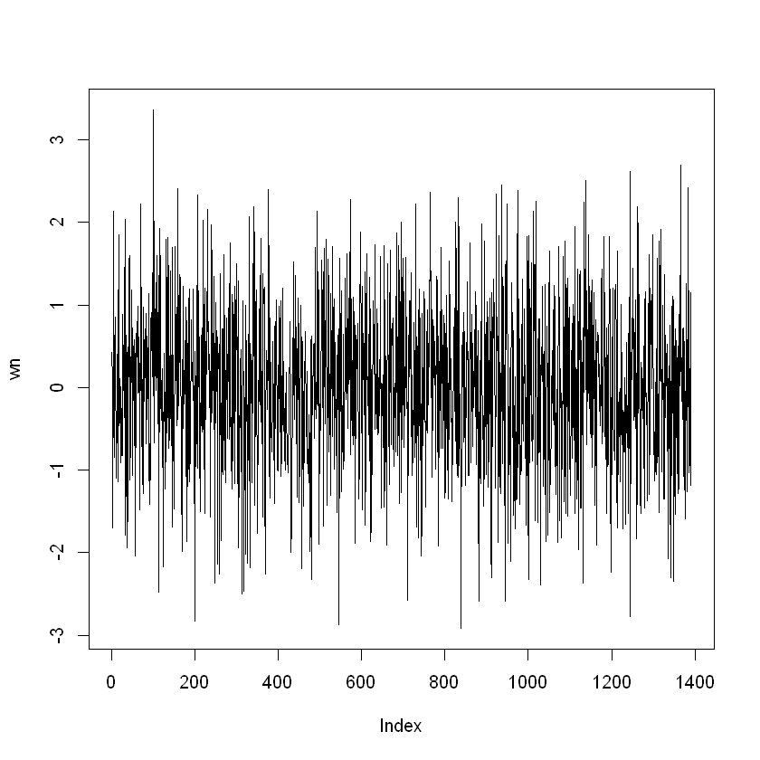

```r
set.seed(20210528)
wn <- rnorm(n_data)
plot(wn, type="l")
```

> (2) G7国のMSCIデータの対数を取ったものを$p_t$とし， $$ p_t = \alpha + \beta wn_t + \varepsilon_t $$ という回帰モデルを推定し，表6.1と同様の表を作成せよ． また，見せかけの会期の現象が見られるかどうか答えよ

対数データを作成して回帰する

```r
p_data <- log(msci_day[, -1])
lm_result <- lapply(p_data, function(x) lm(x~wn))
lapply(lm_result, summary)
```

```
$ca

Call:
lm(formula = x ~ wn)

Residuals:
     Min       1Q   Median       3Q      Max
-0.71221 -0.29085  0.03582  0.27395  0.63868

Coefficients:
             Estimate Std. Error t value Pr(>|t|)
(Intercept)  7.042565   0.009517 739.972   <2e-16 ***
wn          -0.005280   0.009504  -0.556    0.579
---
Signif. codes:  0 '***' 0.001 '**' 0.01 '*' 0.05 '.' 0.1 ' ' 1

Residual standard error: 0.3549 on 1389 degrees of freedom
Multiple R-squared:  0.0002221,	Adjusted R-squared:  -0.0004976
F-statistic: 0.3086 on 1 and 1389 DF,  p-value: 0.5786


$fr

Call:
lm(formula = x ~ wn)

Residuals:
     Min       1Q   Median       3Q      Max
-0.71721 -0.19781 -0.00694  0.26770  0.44830

Coefficients:
             Estimate Std. Error t value Pr(>|t|)
(Intercept)  7.323582   0.007720 948.640   <2e-16 ***
wn          -0.004361   0.007709  -0.566    0.572
---
Signif. codes:  0 '***' 0.001 '**' 0.01 '*' 0.05 '.' 0.1 ' ' 1

Residual standard error: 0.2879 on 1389 degrees of freedom
Multiple R-squared:  0.0002303,	Adjusted R-squared:  -0.0004895
F-statistic:  0.32 on 1 and 1389 DF,  p-value: 0.5717
```

[output cut: 90 more lines]

```

Residuals:
     Min       1Q   Median       3Q      Max
-0.41674 -0.08800  0.00481  0.12090  0.25807

Coefficients:
             Estimate Std. Error  t value Pr(>|t|)
(Intercept)  7.041377   0.004068 1730.907   <2e-16 ***
wn          -0.001615   0.004062   -0.398    0.691
---
Signif. codes:  0 '***' 0.001 '**' 0.01 '*' 0.05 '.' 0.1 ' ' 1

Residual standard error: 0.1517 on 1389 degrees of freedom
Multiple R-squared:  0.0001138,	Adjusted R-squared:  -0.0006061
F-statistic: 0.1581 on 1 and 1389 DF,  p-value: 0.691
```

表6.1っぽくする

```r
table_6_1 <- tibble(
    country = names(lm_result),
    beta = sapply(lm_result, function(x) coef(x)["wn"]),
    p = sapply(lm_result, function(x) summary(x)$coefficients["wn", "Pr(>|t|)"]),
    r2 = sapply(lm_result, function(x) summary(x)$adj.r.squared)
)
table_6_1
```

A tibble: 7 × 4

| country <chr> | beta <dbl> | p <dbl> | r2 <dbl> |
| --- | --- | --- | --- |
| ca | -0.005280016 | 0.5786137 | -0.0004976385 |
| fr | -0.004361057 | 0.5717060 | -0.0004894564 |
| ge | -0.005761287 | 0.5394673 | -0.0004486079 |
| it | -0.002609097 | 0.6955566 | -0.0006095805 |
| jp | -0.005003483 | 0.4262475 | -0.0002638117 |
| uk | -0.003522519 | 0.5683039 | -0.0004853549 |
| us | -0.001615093 | 0.6910101 | -0.0006060794 |

いずれも回帰係数のp値は有意な水準ではなく，見せかけの回帰が起こっているとは言えない

> (3) MSCIデータの標本数と同数のランダムウォーク$rw_t$を $$ rw_t = rw_{t-1} + \varepsilon_t, \quad \varepsilon_t \sim \mathrm{iid} N(0, 1) $$ という式に従って，コンピュータを用いて作成せよ．ただし，$rw_0 = 0$とする．

ホワイトノイズを利用して作成する

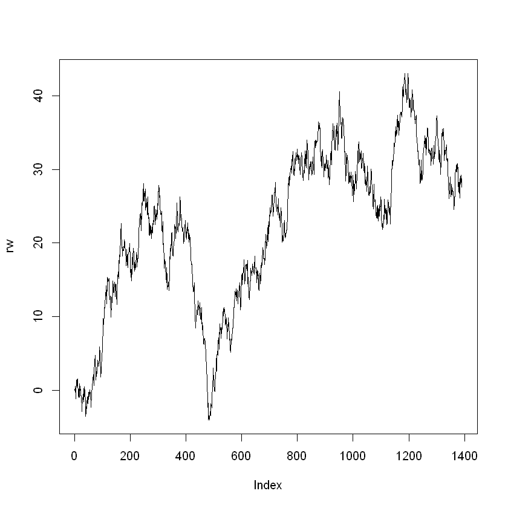

```r
rw <- cumsum(c(0, wn[-n_data]))
plot(rw, type="l")
```

> (4) $p_t$を定数と$rw_t$に回帰したモデル $$ p_t = \alpha + \beta rw_t + \varepsilon_t $$ を推定し，表6.1と同様のひょうを作成せよ．また，見せかけの回帰の現象が見られるかどうか答えよ．

(2)のプログラムを利用する

```r
lm_result2 <- lapply(p_data, function(x) lm(x~rw))
lapply(lm_result2, summary)
```

```
$ca

Call:
lm(formula = x ~ rw)

Residuals:
     Min       1Q   Median       3Q      Max
-0.50784 -0.13760  0.00232  0.15760  0.53086

Coefficients:
             Estimate Std. Error t value Pr(>|t|)
(Intercept) 6.4746375  0.0131150   493.7   <2e-16 ***
rw          0.0258378  0.0005349    48.3   <2e-16 ***
---
Signif. codes:  0 '***' 0.001 '**' 0.01 '*' 0.05 '.' 0.1 ' ' 1

Residual standard error: 0.2168 on 1389 degrees of freedom
Multiple R-squared:  0.6268,	Adjusted R-squared:  0.6265
F-statistic:  2333 on 1 and 1389 DF,  p-value: < 2.2e-16


$fr

Call:
lm(formula = x ~ rw)

Residuals:
     Min       1Q   Median       3Q      Max
-0.42427 -0.13665 -0.01077  0.14846  0.43052

Coefficients:
             Estimate Std. Error t value Pr(>|t|)
(Intercept) 6.8715612  0.0109662  626.61   <2e-16 ***
rw          0.0205645  0.0004473   45.98   <2e-16 ***
---
Signif. codes:  0 '***' 0.001 '**' 0.01 '*' 0.05 '.' 0.1 ' ' 1

Residual standard error: 0.1813 on 1389 degrees of freedom
Multiple R-squared:  0.6035,	Adjusted R-squared:  0.6032
F-statistic:  2114 on 1 and 1389 DF,  p-value: < 2.2e-16
```

[output cut: 90 more lines]

```

Residuals:
      Min        1Q    Median        3Q       Max
-0.199103 -0.081374 -0.003917  0.068206  0.246881

Coefficients:
             Estimate Std. Error t value Pr(>|t|)
(Intercept) 6.8026763  0.0057582 1181.39   <2e-16 ***
rw          0.0108602  0.0002349   46.24   <2e-16 ***
---
Signif. codes:  0 '***' 0.001 '**' 0.01 '*' 0.05 '.' 0.1 ' ' 1

Residual standard error: 0.0952 on 1389 degrees of freedom
Multiple R-squared:  0.6062,	Adjusted R-squared:  0.6059
F-statistic:  2138 on 1 and 1389 DF,  p-value: < 2.2e-16
```

```r
table_6_1_2 <- tibble(
    country = names(lm_result2),
    beta = sapply(lm_result2, function(x) coef(x)["rw"]),
    p = sapply(lm_result2, function(x) summary(x)$coefficients["rw", "Pr(>|t|)"]),
    r2 = sapply(lm_result2, function(x) summary(x)$adj.r.squared)
)
table_6_1_2
```

A tibble: 7 × 4

| country <chr> | beta <dbl> | p <dbl> | r2 <dbl> |
| --- | --- | --- | --- |
| ca | 0.02583778 | 1.378413e-299 | 0.6265386 |
| fr | 0.02056446 | 2.860733e-281 | 0.6031664 |
| ge | 0.02524039 | 8.760987e-289 | 0.6129258 |
| it | 0.01669264 | 3.256517e-231 | 0.5315704 |
| jp | 0.01730323 | 2.163948e-312 | 0.6420545 |
| uk | 0.01620549 | 2.891607e-267 | 0.5843157 |
| us | 0.01086020 | 2.313913e-283 | 0.6059082 |

MSCIデータとは全く無関係に生成したデータだが，どの国の結果でもp値はほぼ0となっている．つまり，見せかけの回帰の現象が見られる．

> (5) $p_t$を定数と$rw_t, rw_{t-1}, p_{t-1}$に回帰したモデル $$ p_t = \alpha + \beta_1 rw_t + \beta_2 rw_{t-1} + \beta_3 p_{t-1} + \varepsilon_t $$ を推定し，$\beta_1$に関して表6.1と同様の表を作成せよ．また，見せかけの回帰の現象が見られるかどうか答えよ．